# Course Project 1

Antonio Vargas

3/11/2020

## Loading and preprocessing the data

Our data set is in a csv format file. We will print the first 5 records after the reading and the right formatting of our variables.

```r
activity = read.csv("activity.csv")
activity$date = as.Date(activity$date, "%Y-%m-%d")
head(activity, 5)
```

```
##   steps       date interval
## 1    NA 2012-10-01        0
## 2    NA 2012-10-01        5
## 3    NA 2012-10-01       10
## 4    NA 2012-10-01       15
## 5    NA 2012-10-01       20
```

## Total, mean and median of steps per day

Building an histogram where is detailed the quantity of steps taken each day.

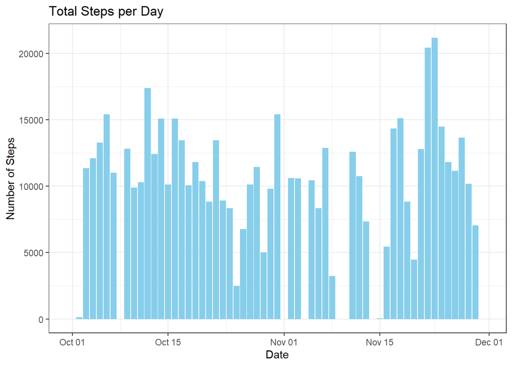

Calculating the mean and median of the total of steps per day.

```
##      Mean Median
## 1 9354.23  10395
```

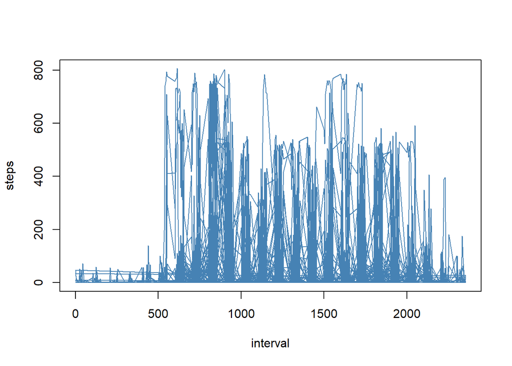

```r
with(activity, plot(interval, steps, type = "l", col = "steelblue"))
```

```r
activity %>% arrange(desc(steps)) %>% head(., 1)
```

```
##   steps       date interval
## 1   806 2012-11-27      615
```

## Imputting missing values

Here we have a table with the quantity of rows wth missing values

```r
activity %>% summarise(steps.NA = sum(is.na(steps)), date.NA = sum(is.na(date)), interval.NA = sum(is.na(interval)))
```

```
##   steps.NA date.NA interval.NA
## 1     2304       0           0
```

Given that we are measuring the steps on intervals of 5 minutes there is the possibility that the subject of study have not moved in the whole interval. Therefore the correct value to assume for the missing observations in the steps feature is zero.

```r
activity_full = activity %>% mutate(steps = coalesce(steps, 0))
head(activity_full)
```

```
##   steps       date interval
## 1     0 2012-10-01        0
## 2     0 2012-10-01        5
## 3     0 2012-10-01       10
## 4     0 2012-10-01       15
## 5     0 2012-10-01       20
## 6     0 2012-10-01       25
```

Now we calculate the mean, median and total of steps given each day and plot the respective histogram.

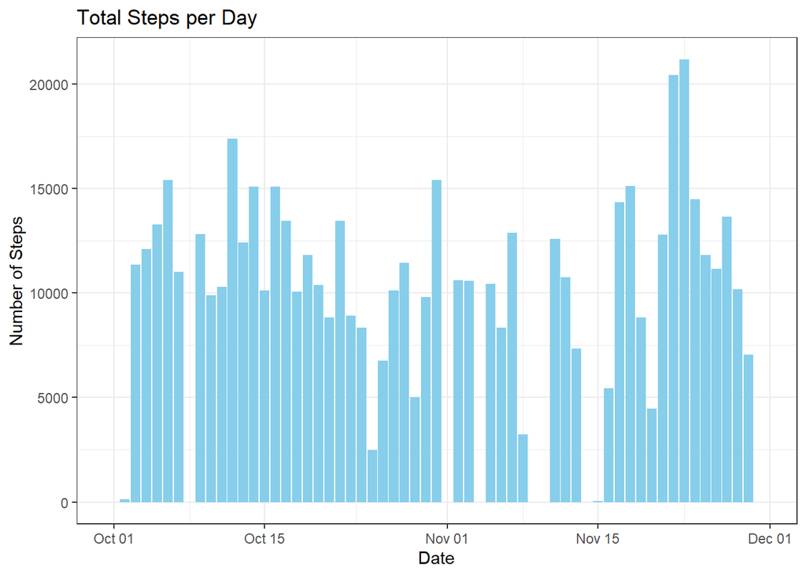

```
##      Mean Median
## 1 9354.23  10395
```

As we can see thre is no variation in the mean nor the median of the quantity of steps done per day.

## Weekdays vs Weekends

First we categorize the type of day (weekday or weekend) that we have in the data set

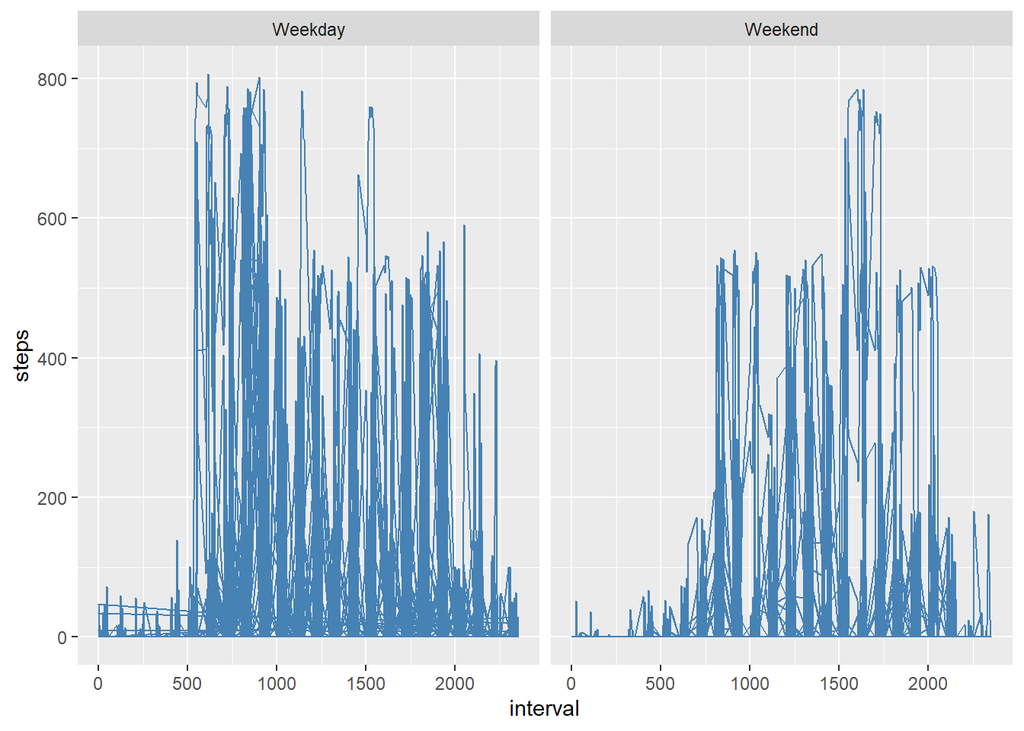

```r
activity_day = activity_full %>% mutate(day = weekdays(date),
                                        week = ifelse(day == "Saturday" | day == "Sunday", "Weekend", "Weekday"))
ggplot(activity_day, aes(interval, steps)) + geom_path(color = "Steelblue") + facet_wrap(week ~ .)
```